We want to predict whether or not there will be fraud based on the variables in the Data.

# Initial Data Exploration

```r
Data <- read.csv("C:/Users/dfoley/Dropbox/Aido/Data_Presentation/Fraud_data.csv")
```

```
## Error: cannot open the connection
```

```r
Data <- read.csv("~/Dropbox/Aido/Data_Presentation/Fraud_data.csv")
summary(Data)
```

```
##      FRAUD             PPSN      SCHEME_CODE LOCATION_CODE
##  Min.   :0.000   0001135J:   1   F1:1113     D1     :  28
##  1st Qu.:0.000   0003334Z:   1   G1:  99     S1     :  26
##  Median :1.000   0006622M:   1   H1: 494     A3     :  24
##  Mean   :0.509   0009177V:   1   H2: 294     G4     :  24
##  3rd Qu.:1.000   0024727R:   1               V3     :  23
##  Max.   :1.000   0028683D:   1               E3     :  22
##                  (Other) :1994               (Other):1853
##         PAY_TYPE          REG_DATE         START_DATE        BIRTH_DATE
##  Basic      :1102   07/09/2008:   4   10/04/2001:   4   02/02/1995:   3
##  Exceptional: 253   15/07/2009:   4   12/05/2012:   4   12/04/1977:   3
##  Supplement : 472   23/04/2012:   4   22/03/2011:   4   15/01/1986:   3
##  Urgent     : 173   01/06/2007:   3   22/05/2012:   4   24/06/1973:   3
##                     02/02/2008:   3   01/11/2012:   3   25/03/1983:   3
##                     02/03/2012:   3   02/05/2009:   3   28/06/1982:   3
##                     (Other)   :1979   (Other)   :1978   (Other)   :1982
##    AGE_YEARS    OCC_CODE   MEANS_FROM_EMP      DELAY       WEEKLY_RATE
##  Min.   :18.0   M   :779   Min.   :  100   Min.   : 0.0   Min.   : 50
##  1st Qu.:29.0   P   : 98   1st Qu.:10700   1st Qu.:14.0   1st Qu.:120
##  Median :37.0   S   :435   Median :21150   Median :21.0   Median :160
##  Mean   :38.7   SS  :687   Mean   :21595   Mean   :21.9   Mean   :154
##  3rd Qu.:47.0   NA's:  1   3rd Qu.:31400   3rd Qu.:29.0   3rd Qu.:190
##  Max.   :79.0              Max.   :57800   Max.   :60.0   Max.   :220
##                                                           NA's   :1
##   PAID_TO_DATE        SEX       MARITAL_STATUS     NO_DEP
##  Min.   :  4160   Female: 974   D:666          Min.   : 0.00
##  1st Qu.: 29160   Male  :1026   M:446          1st Qu.: 2.00
##  Median : 49390                 S:888          Median : 3.00
##  Mean   : 59593                                Mean   : 3.36
##  3rd Qu.: 81600                                3rd Qu.: 4.00
##  Max.   :220290                                Max.   :10.00
##  NA's   :1
##   FUEL_AMOUNT     APPOINTMENT_STATUS  BOOK_NUMBER       CARER_ID
##  Min.   : 40.0   Due       :746      Min.   :10017   Min.   :    0
##  1st Qu.: 70.0   Missed    :391      1st Qu.:19951   1st Qu.:    0
##  Median : 80.0   Up-to-Date:863      Median :29610   Median :    0
##  Mean   : 78.1                       Mean   :29721   Mean   : 1717
##  3rd Qu.: 90.0                       3rd Qu.:39568   3rd Qu.:    0
##  Max.   :140.0                       Max.   :49995   Max.   :49966
##
```

[output cut: 17 more lines]

```
##  Min.   :0.000           Min.   :     0   D1     :  28      Min.   :1.00
##  1st Qu.:0.000           1st Qu.:     0   V3     :  26      1st Qu.:1.00
##  Median :0.000           Median :     0   S1     :  25      Median :1.00
##  Mean   :0.161           Mean   : 58189   A3     :  23      Mean   :1.03
##  3rd Qu.:0.000           3rd Qu.:137688   E3     :  23      3rd Qu.:1.00
##  Max.   :1.000           Max.   :256947   Q2     :  23      Max.   :2.00
##                                           (Other):1852
##     PHONE_NO        PRIORITY_CLAIM
##  Min.   :3.54e+11   Min.   :0.000
##  1st Qu.:3.54e+11   1st Qu.:0.000
##  Median :3.54e+11   Median :0.000
##  Mean   :3.54e+11   Mean   :0.096
##  3rd Qu.:3.54e+11   3rd Qu.:0.000
##  Max.   :3.54e+11   Max.   :1.000
##
```

```r
library(ggplot2)
```

Lets start off with an inital exploration of the  
data to see what variables may impact fraud

```r
cor(Data[,unlist(lapply(Data, is.numeric))], Data$FRAUD)
```

```
##                              [,1]
## FRAUD                    1.000000
## AGE_YEARS               -0.022102
## MEANS_FROM_EMP          -0.691814
## DELAY                    0.557881
## WEEKLY_RATE                    NA
## PAID_TO_DATE                   NA
## NO_DEP                   0.398714
## FUEL_AMOUNT              0.213654
## BOOK_NUMBER              0.035143
## CARER_ID                -0.018821
## PHOTO_VERIFIED           0.003164
## OPEN_CREDIT_LINES        0.012543
## FREE_TRAVEL             -0.011952
## EMPLOYER_NO             -0.023686
## MED_ASSESSMENT           0.149375
## MED_CONDITION_SATISFIED -0.259909
## MORT_OUTSTANDING        -0.001932
## PREF_LANG               -0.006094
## PHONE_NO                       NA
## PRIORITY_CLAIM          -0.053398
```

A few variables look to be correlated with FRAUD  
In particular:

- MEANS_FROM_EMP
- DELAY
- NO_DEP
- FUEL_AMOUNT
- MED_ASSESSMENT
- MED_CONDITION_SATISFIED

No other variables appear to have any strong correlation

```r
table(Data$FRAUD, Data$SEX)
```

```
##
##     Female Male
##   0    483  499
##   1    491  527
```

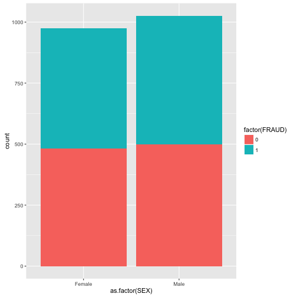

```r
ggplot(Data, aes(x = as.factor(SEX), fill=factor(FRAUD)))+geom_bar()
```

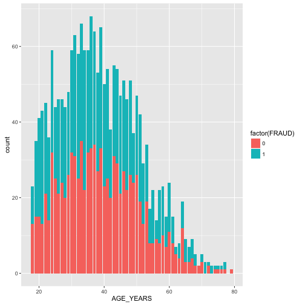

```r
ggplot(Data, aes(x = AGE_YEARS, fill = factor(FRAUD))) + geom_bar()
```

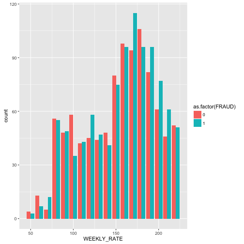

```r
ggplot(Data, aes(x = WEEKLY_RATE, fill = as.factor(FRAUD))) +
  geom_bar(stat = 'count', position = 'dodge')
```

The level of fraud doesnt seem to be particularly  
more prevalent in any age group or at any WEEKLY_RATE.

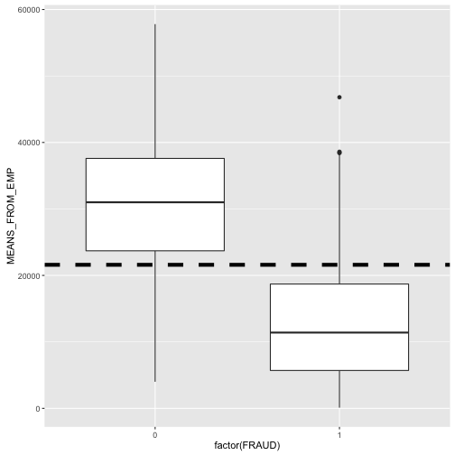

```r
ggplot(Data, aes(x = factor(FRAUD), y =  MEANS_FROM_EMP)) +
  geom_boxplot() + geom_hline(aes(yintercept = mean(MEANS_FROM_EMP)),
                              linetype = 'dashed', lwd = 2)
```

clearly more likely to commit fraud if below the mean value  
of MEAN_FROM_EMP

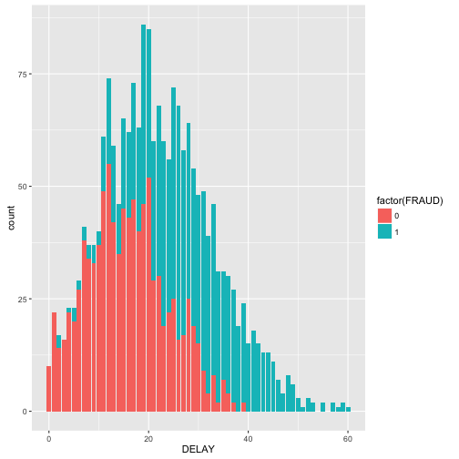

```r
ggplot(Data, aes(x =  DELAY, fill = factor(FRAUD))) + geom_bar()
```

As delay increases there are increasingly higher proportion of FRAUDS

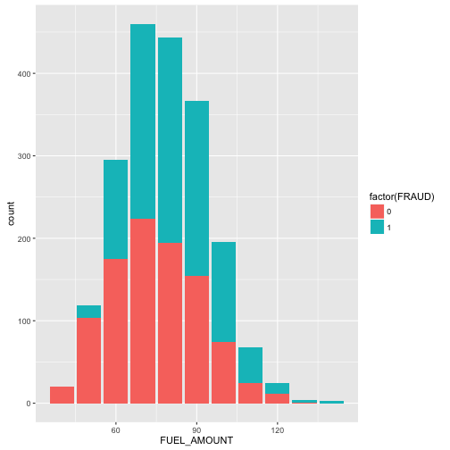

```r
ggplot(Data, aes(x = FUEL_AMOUNT, fill = factor(FRAUD))) + geom_bar()
```

There is also perhaps some relevant information we can use here  
especially at higher fuel levels.

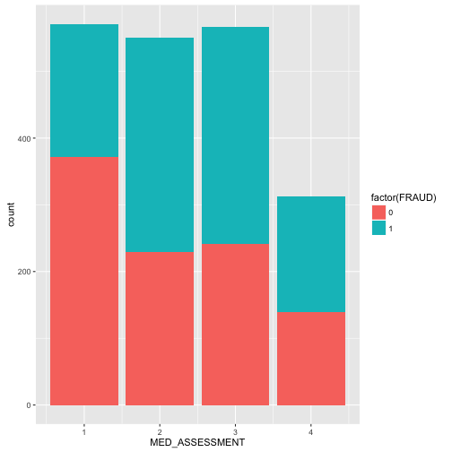

```r
ggplot(Data, aes(x = MED_ASSESSMENT, fill = factor(FRAUD))) + geom_bar()
```

If you score one in medical assesment there is a lower chance you will  
commit FRAUD.

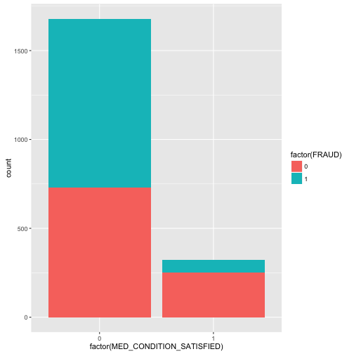

```r
ggplot(Data, aes(x = factor(MED_CONDITION_SATISFIED), fill = factor(FRAUD))) + geom_bar()
```

Assuming 1 is having satisfied medical condition, you are less likely  
to commit fraud.

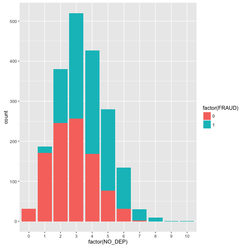

```r
ggplot(Data, aes(x =  factor(NO_DEP), fill = factor(FRAUD))) + geom_bar()
```

# Data Cleaning

Check pattern of missing values using Amelia package

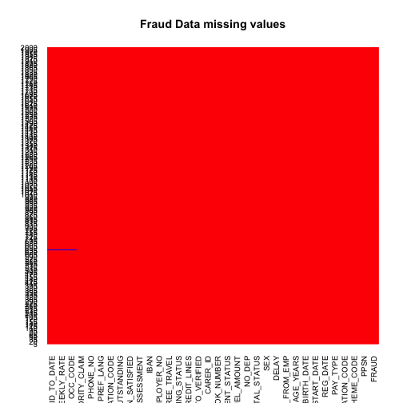

```r
library(Amelia)
missmap(Data, main="Fraud Data missing values",
        col=c("blue", "red"), legend=FALSE)
```

It doesnt look like there is any data missing from the variables we  
are going to be working with  
NO_DEP and DELAY have zero values so we should inspect them to see  
if they are errors or not

```r
summary(Data$MEANS_FROM_EMP)
```

```
##    Min. 1st Qu.  Median    Mean 3rd Qu.    Max.
##     100   10700   21200   21600   31400   57800
```

```r
Data$MEANS_FROM_EMP <- scale(Data$MEANS_FROM_EMP)
```

They dont seem to be errors, however all values of zero are not frauds  
We have also normalised the MEANS_FROM_EMP for any algorithms we use

# Try Logistic Regression

Split into training and test sets (90/10)

```r
Data$MED_ASSESSMENT <- as.factor(Data$MED_ASSESSMENT)
Data$MED_CONDITION_SATISFIED <- as.factor(Data$MED_CONDITION_SATISFIED)
Data$NO_DEP <- as.factor(Data$NO_DEP)

Data$MEANS_NEW <- ifelse(Data$MEANS_FROM_EMP <= mean(Data$MEANS_FROM_EMP),1,0)
brks <- c(0,20,40,60)
Data$DELAY_RANGE <- cut(Data$DELAY, breaks = brks, include.lowest = T)
summary(Data$DELAY_RANGE )
```

```
##  [0,20] (20,40] (40,60]
##     969     919     112
```

```r
brks2 <- c(0,60,100,140)
Data$FUEL_NEW <- cut(Data$FUEL_AMOUNT, breaks = brks2, include.lowest = T)
summary(Data$FUEL_NEW)
```

```
##    [0,60]  (60,100] (100,140]
##       434      1466       100
```

```r
Data$NO_DEP2 <- ifelse(as.numeric(Data$NO_DEP) > 4,1,0)
Data$NO_DEP2 <- as.factor(Data$NO_DEP2)


Data$gp <- runif(dim(Data)[1])
trainingSet <- subset(Data, Data$gp > 0.1)
testSet <- subset(Data,Data$gp <= 0.1)
```

```r
reg1 <- glm(FRAUD ~ MEANS_FROM_EMP + DELAY + NO_DEP +
              FUEL_AMOUNT + MED_ASSESSMENT + MED_CONDITION_SATISFIED,
            data = trainingSet, family =  binomial(link = 'logit'))
summary(reg1)
```

```
##
## Call:
## glm(formula = FRAUD ~ MEANS_FROM_EMP + DELAY + NO_DEP + FUEL_AMOUNT +
##     MED_ASSESSMENT + MED_CONDITION_SATISFIED, family = binomial(link = "logit"),
##     data = trainingSet)
##
## Deviance Residuals:
##     Min       1Q   Median       3Q      Max
## -2.9705  -0.2419   0.0139   0.2466   2.9823
##
## Coefficients:
##                           Estimate Std. Error z value Pr(>|z|)
## (Intercept)               -16.7015   563.4488   -0.03    0.976
## MEANS_FROM_EMP             -2.4510     0.1438  -17.05  < 2e-16 ***
## DELAY                       0.1546     0.0116   13.34  < 2e-16 ***
## NO_DEP1                    15.8684   563.4487    0.03    0.978
## NO_DEP2                    18.1860   563.4486    0.03    0.974
## NO_DEP3                    19.6897   563.4487    0.03    0.972
## NO_DEP4                    20.8543   563.4488    0.04    0.970
## NO_DEP5                    22.2286   563.4489    0.04    0.969
## NO_DEP6                    22.7312   563.4491    0.04    0.968
## NO_DEP7                    26.2694   563.4520    0.05    0.963
## NO_DEP8                    39.3860  1279.0595    0.03    0.975
## NO_DEP9                    45.4584  3996.1029    0.01    0.991
## NO_DEP10                   37.7588  3996.1029    0.01    0.992
## FUEL_AMOUNT                -0.0854     0.0118   -7.24  4.6e-13 ***
## MED_ASSESSMENT2             0.3191     0.2639    1.21    0.227
## MED_ASSESSMENT3             0.4828     0.2619    1.84    0.065 .
## MED_ASSESSMENT4             0.2800     0.3013    0.93    0.353
## MED_CONDITION_SATISFIED1   -1.3605     0.3060   -4.45  8.7e-06 ***
## ---
## Signif. codes:  0 '***' 0.001 '**' 0.01 '*' 0.05 '.' 0.1 ' ' 1
##
## (Dispersion parameter for binomial family taken to be 1)
##
##     Null deviance: 2490.56  on 1796  degrees of freedom
## Residual deviance:  821.78  on 1779  degrees of freedom
## AIC: 857.8
##
## Number of Fisher Scoring iterations: 16
```

Test Fit

```r
fit1 <- predict(reg1, newdata = testSet, type = 'response')
fit1 <- ifelse(fit1 > 0.5,1,0)
misClasificError1 <- mean(fit1 != testSet$FRAUD)
print(paste('Accuracy',1-misClasificError1))
```

```
## [1] "Accuracy 0.891625615763547"
```

# Logistic Part 2

Try and increase performance by using logit on redfined variables

```r
reg2 <- glm(FRAUD ~ MEANS_NEW + DELAY_RANGE + NO_DEP2 +
              FUEL_NEW + MED_ASSESSMENT + MED_CONDITION_SATISFIED,
            data = trainingSet, family =  binomial(link = 'logit'))
summary(reg2)
```

```
##
## Call:
## glm(formula = FRAUD ~ MEANS_NEW + DELAY_RANGE + NO_DEP2 + FUEL_NEW +
##     MED_ASSESSMENT + MED_CONDITION_SATISFIED, family = binomial(link = "logit"),
##     data = trainingSet)
##
## Deviance Residuals:
##     Min       1Q   Median       3Q      Max
## -2.7119  -0.3932   0.0001   0.4666   2.7539
##
## Coefficients:
##                          Estimate Std. Error z value Pr(>|z|)
## (Intercept)                -3.769      0.272  -13.87  < 2e-16 ***
## MEANS_NEW                   3.053      0.156   19.53  < 2e-16 ***
## DELAY_RANGE(20,40]          2.083      0.153   13.58  < 2e-16 ***
## DELAY_RANGE(40,60]         18.268    327.175    0.06   0.9555
## NO_DEP21                    1.037      0.170    6.08  1.2e-09 ***
## FUEL_NEW(60,100]            0.580      0.202    2.87   0.0041 **
## FUEL_NEW(100,140]           0.307      0.397    0.77   0.4394
## MED_ASSESSMENT2             0.512      0.217    2.36   0.0184 *
## MED_ASSESSMENT3             0.667      0.218    3.05   0.0023 **
## MED_ASSESSMENT4             0.216      0.248    0.87   0.3837
## MED_CONDITION_SATISFIED1   -1.164      0.251   -4.63  3.7e-06 ***
## ---
## Signif. codes:  0 '***' 0.001 '**' 0.01 '*' 0.05 '.' 0.1 ' ' 1
##
## (Dispersion parameter for binomial family taken to be 1)
##
##     Null deviance: 2490.6  on 1796  degrees of freedom
## Residual deviance: 1211.7  on 1786  degrees of freedom
## AIC: 1234
##
## Number of Fisher Scoring iterations: 16
```

Test Fit

```r
fit <- predict(reg2, newdata = testSet, type = 'response')
fit <- ifelse(fit> 0.5,1,0)

misClasificError <- mean(fit != testSet$FRAUD)
print(paste('Accuracy',1-misClasificError))
```

```
## [1] "Accuracy 0.862068965517241"
```

These variables dont have apppeared to make the model more  
accuarte. Next we try Random Forests on the original set of variables.

# Random Forest

Next we wil try a randomforest wichi tend to perform well with this kind of problem

```r
library(randomForest)
```

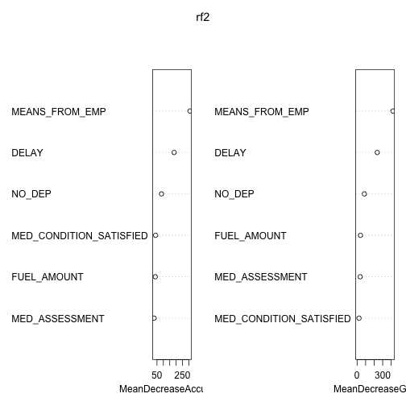

```r
set.seed(111)
rf2 <- randomForest(as.factor(FRAUD) ~ MEANS_FROM_EMP + DELAY + NO_DEP +
              FUEL_AMOUNT + MED_ASSESSMENT + MED_CONDITION_SATISFIED,
                  data = trainingSet,
                    importance = TRUE,
                    ntree = 2000)
varImpPlot(rf2)
```

```r
fit3 <- predict(rf2, newdata = testSet, type = 'response')
misClasificError3 <- mean(fit3 != testSet$FRAUD)
print(paste('Accuracy',1-misClasificError3))
```

```
## [1] "Accuracy 0.886699507389163"
```

Finally we perform a conditional random forest from the party package

```r
library(party)
set.seed(333)
rf1 <- cforest(as.factor(FRAUD) ~ MEANS_FROM_EMP + DELAY + NO_DEP +
              FUEL_AMOUNT + MED_ASSESSMENT + MED_CONDITION_SATISFIED,
                  data = trainingSet,
               controls=cforest_unbiased(ntree=2000, mtry=3))



fit4 <- predict(rf1, newdata = testSet, type = 'response')
misClasificError4 <- mean(fit4 != testSet$FRAUD)
print(paste('Accuracy',1-misClasificError4))
```

```
## [1] "Accuracy 0.87192118226601"
```

```r
formula = as.factor(FRAUD) ~ MEANS_NEW + DELAY_RANGE +
                  NO_DEP2 + FUEL_NEW + MED_ASSESSMENT +
                  MED_CONDITION_SATISFIED
library(caret)
train_control <- trainControl(method = 'cv', number = 10)
modelLog = train(formula, data=trainingSet, method="glm", family=binomial,
                 trControl=train_control)
print(modelLog)
```

```
## Generalized Linear Model
##
## 1797 samples
##   38 predictors
##    2 classes: '0', '1'
##
## No pre-processing
## Resampling: Cross-Validated (10 fold)
##
## Summary of sample sizes: 1618, 1618, 1617, 1617, 1618, 1617, ...
##
## Resampling results
##
##   Accuracy  Kappa  Accuracy SD  Kappa SD
##   0.8       0.7    0.02         0.04
##
##
```

Try on RandomForest

```r
train_control2 <- trainControl(method = 'cv', number = 10)
modelLog2 = train(formula, data=trainingSet, method="rf",
                 trControl=train_control)
print(modelLog2)
```

```
## Random Forest
##
## 1797 samples
##   38 predictors
##    2 classes: '0', '1'
##
## No pre-processing
## Resampling: Cross-Validated (10 fold)
##
## Summary of sample sizes: 1618, 1617, 1618, 1617, 1618, 1617, ...
##
## Resampling results across tuning parameters:
##
##   mtry  Accuracy  Kappa  Accuracy SD  Kappa SD
##   2     0.8       0.7    0.03         0.07
##   6     0.8       0.7    0.03         0.06
##   10    0.8       0.7    0.03         0.07
##
## Accuracy was used to select the optimal model using  the largest value.
## The final value used for the model was mtry = 2.
```

```r
library(glmnet)
```

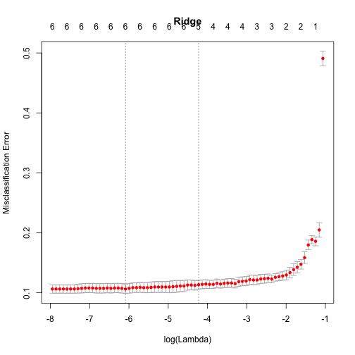

```r
x.m = data.matrix(trainingSet[,c(11,12,17,18,28,29)])
y.m = trainingSet$FRAUD
cvfit.m.ridge = cv.glmnet(x.m, y.m,
                          family = "binomial",
                          alpha = 1,
                          type.measure = "class")
plot(cvfit.m.ridge, main = "Ridge")
```

```r
coef(cvfit.m.ridge, s = "lambda.min")
```

```
## 7 x 1 sparse Matrix of class "dgCMatrix"
##                                1
## (Intercept)             -1.78465
## MEANS_FROM_EMP          -2.29467
## DELAY                    0.14577
## NO_DEP                   1.15389
## FUEL_AMOUNT             -0.06609
## MED_ASSESSMENT           0.08467
## MED_CONDITION_SATISFIED -1.24650
```

```r
pred2 = predict(cvfit.m.ridge, s = 'lambda.min',
               newx = data.matrix(testSet[,c(11,12,17,18,28,29)]),
               type="class")

misClasificError_ridge <- mean(pred2 != testSet$FRAUD)
print(paste('Accuracy',1-misClasificError_ridge))
```

```
## [1] "Accuracy 0.876847290640394"
```